# Actividad_GitHub

Cristina Ramos

2025-06-17

# Cargar librerías

```r
library(palmerpenguins)
```

```r
library(ggplot2)
library(dplyr)
library(tidyr)
library(plotly)
```

# Introducción

Este informe explora el dataset penguins, el cual contiene información morfológica de pingüinos de tres especies que habitan distintas islas en la región Antártica. A partir de una limpieza y transformación inicial, se realizará un análisis gráfico y exploratorio, incluyendo visualizaciones en 3D para facilitar la identificación de patrones multivariados.

# Preparación de los datos

```r
# Para evitar que salga el doble símbolo de numeral al principio de cada fila
# Cargar y limpiar el dataset
df_pinguinos <- na.omit(penguins)

# Renombrar columnas al espaniol
colnames(df_pinguinos) <- c("especie", "isla", "longitud_pico_mm", "profundidad_pico_mm",
                            "longitud_aleta_mm", "masa_corporal_g", "sexo", "anio")

# Vista previa
knitr::kable(head(df_pinguinos), caption = "Primeras filas del dataset Pinguinos")
```

Primeras filas del dataset Pinguinos

| especie | isla | longitud_pico_mm | profundidad_pico_mm | longitud_aleta_mm | masa_corporal_g | sexo | anio |
| --- | --- | --- | --- | --- | --- | --- | --- |
| Adelie | Torgersen | 39.1 | 18.7 | 181 | 3750 | male | 2007 |
| Adelie | Torgersen | 39.5 | 17.4 | 186 | 3800 | female | 2007 |
| Adelie | Torgersen | 40.3 | 18.0 | 195 | 3250 | female | 2007 |
| Adelie | Torgersen | 36.7 | 19.3 | 193 | 3450 | female | 2007 |
| Adelie | Torgersen | 39.3 | 20.6 | 190 | 3650 | male | 2007 |
| Adelie | Torgersen | 38.9 | 17.8 | 181 | 3625 | female | 2007 |

# Distribuciones por especie

## Masa corporal

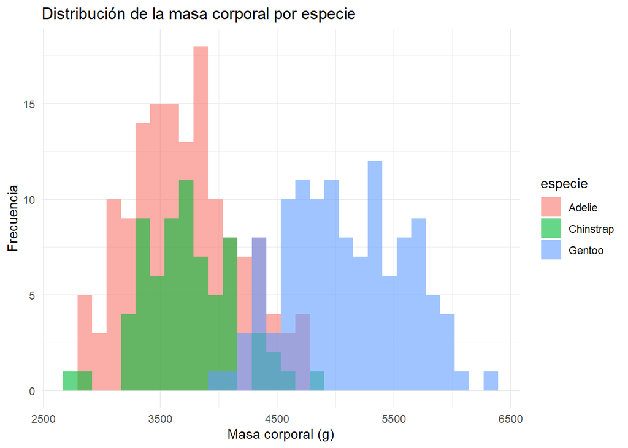

```r
ggplot(df_pinguinos, aes(x = masa_corporal_g, fill = especie)) +
  geom_histogram(position = "identity", alpha = 0.6, bins = 30) +
  labs(title = "Distribución de la masa corporal por especie",
       x = "Masa corporal (g)", y = "Frecuencia") +
  theme_minimal()
```

**Análisis:** Se observa que la especie Gentoo presenta masas corporales más elevadas, mientras que Adelie tiende a ser más ligera.

## Relación entre longitud de pico y aleta

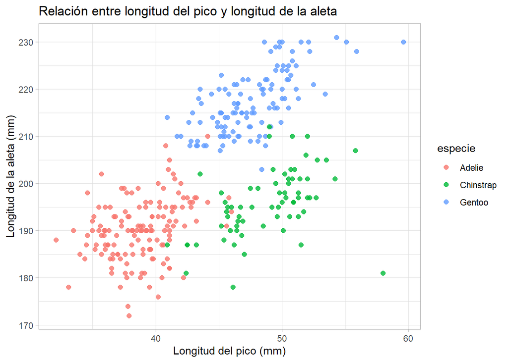

```r
ggplot(df_pinguinos, aes(x = longitud_pico_mm, y = longitud_aleta_mm, color = especie)) +
  geom_point(size = 2, alpha = 0.8) +
  labs(title = "Relación entre longitud del pico y longitud de la aleta",
       x = "Longitud del pico (mm)", y = "Longitud de la aleta (mm)") +
  theme_light()
```

**Análisis:** Existe una correlación moderada entre ambas variables. Gentoo se distingue claramente por mayor tamaño corporal general.

# Visualización 3D

Para observar mejor la distribución multivariada, se construye un gráfico 3D interactivo utilizando el paquete **plotly**

```r
plot_ly(df_pinguinos,
        x = ~longitud_pico_mm,
        y = ~longitud_aleta_mm,
        z = ~masa_corporal_g,
        color = ~especie,
        colors = c("darkorange", "steelblue", "darkgreen"),
        type = "scatter3d",
        mode = "markers") %>%
  layout(title = "Gráfico 3D: Pico vs Aleta vs Masa Corporal",
         scene = list(
           xaxis = list(title = "Longitud Pico (mm)"),
           yaxis = list(title = "Longitud Aleta (mm)"),
           zaxis = list(title = "Masa Corporal (g)")
         ))
```

[interactive chart not shown]

**Análisis:** Esta visualización 3D permite distinguir claramente conglomerados por especie. Gentoo se agrupa en valores altos de las tres variables.

# Comparación por sexo

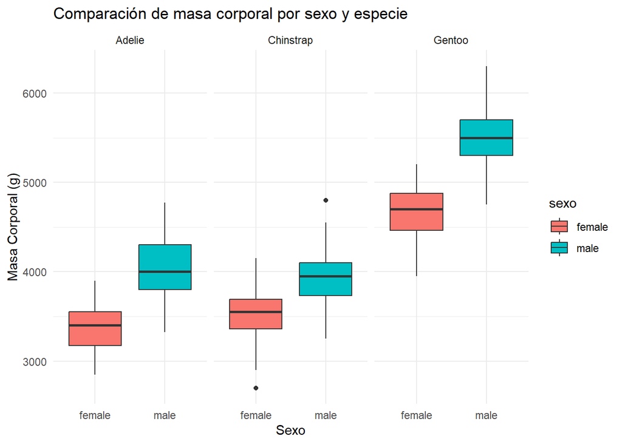

```r
ggplot(df_pinguinos, aes(x = sexo, y = masa_corporal_g, fill = sexo)) +
  geom_boxplot() +
  facet_wrap(~ especie) +
  labs(title = "Comparación de masa corporal por sexo y especie",
       x = "Sexo", y = "Masa Corporal (g)") +
  theme_minimal()
```

**Análisis:** En todas las especies, los machos tienden a tener una mayor masa corporal que las hembras, lo que sugiere un dimorfismo sexual morfológico.

# Conclusiones

- Se evidencian diferencias marcadas entre especies en variables clave como - masa corporal y longitud de aleta.
- Gentoo presenta dimensiones corporales consistentemente más altas.
- El gráfico 3D permitió visualizar la estructura multivariada de forma clara.
- El dimorfismo sexual es evidente en todas las especies.
- Este análisis básico puede extenderse a modelos predictivos o dashboards interactivos.